# Challenge 1

[figure not shown]

# You are in charge of the cake for a child’s birthday.

# You have decided the cake will have one candle for each year of their total age.

# They will only be able to blow out the tallest of the candles.

# Count how many candles are tallest.

# Candles = [4,4,1,3]

# eg 2 candels = [4,4,1,3,5] one

# The maximum height candles are 4 units high. There are 2 of them, so return 2.

# Note please dont use MAX function

```python
a
```

[output not shown]

```python
candles = [4,4,1,3]

max_num = 0
for num in candles:
    if(num > max_num):
        max_num=num

print(candles.count(max_num))

#1st iteration - 4 > 0 ---> True
#2nd itr ---> 4>4 ---- False
#3r itr ----> 1>4 ----> False
#4r itr ----> 3>4 ----> False
```

```
2
```

```python
candles = [4,4,1,3,5,5,5,5]

max_num = 0
for num in candles:
    if(num > max_num):
        max_num=num

print(candles.count(max_num)," candles are tallest")

#1st iteration - 4 > 0 ---> True
#2nd itr ---> 4>4 ---- False
#3r itr ----> 1>4 ----> False
#4r itr ----> 3>4 ----> False
```

```
4  candles are tallest
```

```python
candles.count(max(candles))
```

```
4
```

```python
# candles.sort()
# max_num = candles[-1]
# candles.count(max_num)
```

[output not shown]

There are three cups on a table, at positions A, B and C. At the start, there is a ball hidden under the cup at position B.

However, I perform a number of swaps on the cups, which is rotated as two letters. For example, if I swap the cups at positions A and B, I could rotate this as AB or BA.

Create a function which returns the letter position that the ball is at, once I finish swapping the cups. The swaps will be given to you as a list.

Worked Example cup_swapping(['AB', 'CA', 'AB']) ➞ 'C'

Ball begins at position B. Cups A and B swap, so ball is at position A. Cups C and A swap, so ball is at position C. Cups A and B swap, but the ball is at position C, so it doesn't move.

Examples cup_swapping(['AB', 'CA']) ➞ 'C'

cup_swapping(['AC', 'CA', 'CA', 'AC']) ➞ 'B'

cup_swapping(['BA', 'AC', 'CA', 'BC']) ➞ 'A'

```python
ball_position = 'B'
#1st for loop ab
for swap in(['AB', 'CA']):
    #swap = AB
    #2nd iteration  swap =CA and ball bosition now is A
    if ball_position in swap:
        #True  ----> if fase it will go out of the if statement initial ball pos is the o/p
        #2nd for loop
        #2nd iteration True
        if swap[0]==ball_position:
            #False --- then go to else
            #Swap[0]----> A swap[1]--->B
            #2nd iteration swap[0]--->C and here it is false
            ball_position=swap[1]
        else:
            ball_position = swap[0]
            #swap[0] ---> A
            #2nd iteration ----C
print("Ball Position is ", ball_position)


#B
#AB
#A
```

```
Ball Position is  C
```

```python
ball_position = 'B'
for swap in(['AB', 'CA']):
    print(swap)
```

```
AB
CA
```

```python
swap='AB'
swap[1]
```

```
'B'
```

```python
if ball_position in swap:
        print('yes')
else:
    print('No')
```

```
yes
```

Hailstone Sequence Algorithm

Take a number (says ‘n’) as an input.

Print the value of ‘n’.

while n != 1

a) Print the value of ‘n’.

b) If ‘n’ is odd, calculate the next number as n*3+1.

c) If ‘n’ is even, calculate the next number as n/2.

Examples

Input : 10

Output (Hailstone Sequence): 10 -> 5 -> 16 -> 8 -> 4 -> 2 ->1

Input : 17

Output (Hailstone Sequence): 17 -> 52 -> 26 -> 13 -> 40 -> 20 ->10 -> 5 -> 16 -> 8 -> 4 -> 2 -> 1

# Build a calci which will calculate + , - , *, /

```python
def Calcul(x,y):
    a=x+y
    b=x-y
    c=x*y
    d=x/y
    return a,b,c,d
```

```python
Addition, sub, mul, div = Calcul(1,2)
print("X = 1 and y = 2")
print("Addition of x and y = ",Addition)
print("Sub of x and y = ",sub)
print("mul of x and y = ",mul)
print("div of x and y = ",div)
```

```
X = 1 and y = 2
Addition of x and y =  3
Sub of x and y =  -1
mul of x and y =  2
div of x and y =  0.5
```

# Read the data

```python
import pandas as pd
movie_df= pd.read_csv('IMDB-Movie-Data.csv')
```

# View data

```python
movie_df.head(1)
```

| Title | Rank | Genre | Description | Director | Actors | Year | Runtime (Minutes) | Rating | Votes | Revenue (Millions) | Metascore |
| --- | --- | --- | --- | --- | --- | --- | --- | --- | --- | --- | --- |
| Guardians of the Galaxy | 1 | Action,Adventure,Sci-Fi | A group of intergalactic criminals are forced ... | James Gunn | Chris Pratt, Vin Diesel, Bradley Cooper, Zoe S... | 2014 | 121 | 8.1 | 757074 | 333.13 | 76.0 |

```python
movie_df.tail(1)
```

| Title | Rank | Genre | Description | Director | Actors | Year | Runtime (Minutes) | Rating | Votes | Revenue (Millions) | Metascore |
| --- | --- | --- | --- | --- | --- | --- | --- | --- | --- | --- | --- |
| Nine Lives | 1000 | Comedy,Family,Fantasy | A stuffy businessman finds himself trapped ins... | Barry Sonnenfeld | Kevin Spacey, Jennifer Garner, Robbie Amell,Ch... | 2016 | 87 | 5.3 | 12435 | 19.64 | 11.0 |

```python
movie_df.shape
```

```
(1000, 11)
```

# Handling duplicates

```python
temp = movie_df.copy()
```

```python
temp.shape
```

```
(1000, 11)
```

```python
temp_without_duplicates = temp.drop_duplicates()
```

```python
temp_without_duplicates.shape
```

```
(1000, 11)
```

```python
temp=movie_df.append(movie_df)
temp.shape
```

```
(2000, 11)
```

```python
temp_without_duplicates = temp.drop_duplicates()
```

```python
temp_without_duplicates.shape
```

```
(1000, 11)
```

```python
# drop_duplicates(Keep= first, last , all)
#first drop except 1st occurance
#false drop all dup
```

# column cleanup

```python
movie_df.columns
#best practice use _ inplace of space use _ or any other symbole and keep it in lower case
```

```
Index(['Rank', 'Genre', 'Description', 'Director', 'Actors', 'Year',
       'Runtime (Minutes)', 'Rating', 'Votes', 'Revenue (Millions)',
       'Metascore'],
      dtype='object')
```

```python
movie_df.rename(columns={'Runtime (Minutes)':'Runtime',
                        'Revenue (Millions)':'Revenue'}, inplace=True)
```

```python
for col in movie_df.columns:
    print(col)
```

[output not shown]

```python
movie_df.columns = [col.lower() for col in movie_df]
```

```python
movie_df.columns
```

```
Index(['rank', 'genre', 'description', 'director', 'actors', 'year', 'runtime',
       'rating', 'votes', 'revenue', 'metascore'],
      dtype='object')
```

# Working with missing values

```python
# Missing values - values those are not pupoulated
```

```python
#Identify the missing values
movie_df.isnull().sum()
```

```
rank             0
genre            0
description      0
director         0
actors           0
year             0
runtime          0
rating           0
votes            0
revenue        128
metascore       64
dtype: int64
```

```python
temp = movie_df.copy()
```

```python
temp1=temp.dropna()
#temp.dropna(inplace= True)
```

```python
temp1.shape
```

```
(838, 11)
```

```python
temp1.isnull().sum()
```

```
rank           0
genre          0
description    0
director       0
actors         0
year           0
runtime        0
rating         0
votes          0
revenue        0
metascore      0
dtype: int64
```

# Imputation

```python
#treating missing values
#mean median mode
#mean ---> when data is normal distrubuted and if variable is numeric
#median --- > its not normally distributed and if variable is numeric
#mode ----> no of occurance
#we also buld ML modle to fill the missing value
temp1.revenue.mean()
```

```
84.56455847255368
```

```python
temp.shape
```

```
(1000, 11)
```

```python
temp.isnull().sum()
```

```
rank             0
genre            0
description      0
director         0
actors           0
year             0
runtime          0
rating           0
votes            0
revenue        128
metascore       64
dtype: int64
```

```python
temp.revenue.fillna(temp.revenue.mean(),inplace=True)
```

```python
temp.shape
```

```
(1000, 11)
```

```python
temp.isnull().sum()
```

```
rank            0
genre           0
description     0
director        0
actors          0
year            0
runtime         0
rating          0
votes           0
revenue         0
metascore      64
dtype: int64
```

# Understanding your variables

```python
temp.describe()
```

|  | rank | year | runtime | rating | votes | revenue | metascore |
| --- | --- | --- | --- | --- | --- | --- | --- |
| count | 1000.000000 | 1000.000000 | 1000.000000 | 1000.000000 | 1.000000e+03 | 1000.000000 | 936.000000 |
| mean | 500.500000 | 2012.783000 | 113.172000 | 6.723200 | 1.698083e+05 | 82.956376 | 58.985043 |
| std | 288.819436 | 3.205962 | 18.810908 | 0.945429 | 1.887626e+05 | 96.412043 | 17.194757 |
| min | 1.000000 | 2006.000000 | 66.000000 | 1.900000 | 6.100000e+01 | 0.000000 | 11.000000 |
| 25% | 250.750000 | 2010.000000 | 100.000000 | 6.200000 | 3.630900e+04 | 17.442500 | 47.000000 |
| 50% | 500.500000 | 2014.000000 | 111.000000 | 6.800000 | 1.107990e+05 | 60.375000 | 59.500000 |
| 75% | 750.250000 | 2016.000000 | 123.000000 | 7.400000 | 2.399098e+05 | 99.177500 | 72.000000 |
| max | 1000.000000 | 2016.000000 | 191.000000 | 9.000000 | 1.791916e+06 | 936.630000 | 100.000000 |

```python
temp.actors.describe()
```

```
count                                                  1000
unique                                                  996
top       Shia LaBeouf, Megan Fox, Josh Duhamel, Tyrese ...
freq                                                      2
Name: actors, dtype: object
```

# Relationship between continious variables

```python
#relationship between 2 variables
#vehicle power and mil --- higher power lower mil,lower power higher mil
#value range from -1 to 1
temp.corr()
```

|  | rank | year | runtime | rating | votes | revenue | metascore |
| --- | --- | --- | --- | --- | --- | --- | --- |
| rank | 1.000000 | -0.261605 | -0.221739 | -0.219555 | -0.283876 | -0.252996 | -0.191869 |
| year | -0.261605 | 1.000000 | -0.164900 | -0.211219 | -0.411904 | -0.117562 | -0.079305 |
| runtime | -0.221739 | -0.164900 | 1.000000 | 0.392214 | 0.407062 | 0.247834 | 0.211978 |
| rating | -0.219555 | -0.211219 | 0.392214 | 1.000000 | 0.511537 | 0.189527 | 0.631897 |
| votes | -0.283876 | -0.411904 | 0.407062 | 0.511537 | 1.000000 | 0.607941 | 0.325684 |
| revenue | -0.252996 | -0.117562 | 0.247834 | 0.189527 | 0.607941 | 1.000000 | 0.133328 |
| metascore | -0.191869 | -0.079305 | 0.211978 | 0.631897 | 0.325684 | 0.133328 | 1.000000 |

# Dataframe slicing, selecting, extracting

```python
#temp['runtime']

iloc and loc
```

```python
import pandas as pd
movie_df= pd.read_csv('IMDB-Movie-Data.csv',index_col='Title')
```

```python
temp.loc['Split']
```

```
rank                                                           3
genre                                            Horror,Thriller
description    Three girls are kidnapped by a man with a diag...
director                                      M. Night Shyamalan
actors         James McAvoy, Anya Taylor-Joy, Haley Lu Richar...
year                                                        2016
runtime                                                      117
rating                                                       7.3
votes                                                     157606
revenue                                                   138.12
metascore                                                     62
Name: Split, dtype: object
```

```python
temp.iloc[19]
```

```
rank                                                          20
genre                                       Drama,Mystery,Sci-Fi
description    When twelve mysterious spacecraft appear aroun...
director                                        Denis Villeneuve
actors         Amy Adams, Jeremy Renner, Forest Whitaker,Mich...
year                                                        2016
runtime                                                      116
rating                                                         8
votes                                                     340798
revenue                                                    100.5
metascore                                                     81
Name: Arrival, dtype: object
```

```python
temp.iloc[-1]
```

```
rank                                                        1000
genre                                      Comedy,Family,Fantasy
description    A stuffy businessman finds himself trapped ins...
director                                        Barry Sonnenfeld
actors         Kevin Spacey, Jennifer Garner, Robbie Amell,Ch...
year                                                        2016
runtime                                                       87
rating                                                       5.3
votes                                                      12435
revenue                                                    19.64
metascore                                                     11
Name: Nine Lives, dtype: object
```

# Group by

```python
temp.head(1)
```

| Title | rank | genre | description | director | actors | year | runtime | rating | votes | revenue | metascore |
| --- | --- | --- | --- | --- | --- | --- | --- | --- | --- | --- | --- |
| Guardians of the Galaxy | 1 | Action,Adventure,Sci-Fi | A group of intergalactic criminals are forced ... | James Gunn | Chris Pratt, Vin Diesel, Bradley Cooper, Zoe S... | 2014 | 121 | 8.1 | 757074 | 333.13 | 76.0 |

```python
movie_df.year.value_counts()
```

```
2016    297
2015    127
2014     98
2013     91
2012     64
2011     63
2010     60
2007     53
2008     52
2009     51
2006     44
Name: year, dtype: int64
```

```python
pd.DataFrame(movie_df.rating.value_counts()).sort_values(by="rating")
```

|  | rating |
| --- | --- |
| 1.9 | 1 |
| 9.0 | 1 |
| 3.2 | 1 |
| 4.1 | 1 |
| 4.5 | 1 |
| 4.4 | 1 |
| 4.0 | 1 |
| 3.7 | 2 |
| 3.5 | 2 |
| 4.2 | 2 |
| 2.7 | 2 |
| 8.8 | 2 |
| 8.6 | 3 |
| 3.9 | 3 |
| 5.0 | 4 |
| 4.8 | 4 |
| 4.3 | 4 |
| 8.4 | 4 |
| 5.1 | 5 |
| 4.6 | 5 |
| 8.5 | 6 |
| 4.7 | 6 |
| 8.3 | 7 |
| 4.9 | 7 |
| 8.2 | 10 |
| 5.2 | 11 |
| 5.4 | 12 |
| 5.3 | 12 |
| 5.5 | 14 |
| 5.6 | 17 |
| 5.9 | 19 |
| 8.0 | 19 |
| 5.7 | 21 |
| 7.9 | 23 |
| 8.1 | 26 |
| 6.0 | 26 |
| 5.8 | 26 |
| 7.7 | 27 |
| 7.6 | 27 |
| 6.1 | 31 |
| 6.9 | 31 |
| 7.4 | 33 |
| 6.4 | 35 |
| 7.5 | 35 |
| 6.8 | 37 |
| 6.2 | 37 |
| 7.8 | 40 |
| 6.5 | 40 |
| 7.3 | 42 |
| 7.2 | 42 |
| 6.6 | 42 |
| 6.3 | 44 |
| 7.0 | 46 |
| 6.7 | 48 |
| 7.1 | 52 |

```python
movie_df.columns
```

[output not shown]

```python
movie_df.groupby('year')['revenue'].mean()
```

```
year
2006     86.296667
2007     87.882245
2008     99.082745
2009    112.601277
2010    105.081579
2011     87.612258
2012    107.973281
2013     87.121818
2014     85.078723
2015     78.355044
2016     54.690976
Name: revenue, dtype: float64
```

```python
movies_df = pd.read_csv("IMDB-Movie-Data.csv")
movies_df.columns = [col.lower() for col in movies_df]

#movies_df.columns
movies_df.plot(kind='scatter', x='rating', y='revenue (millions)', title='Revenue (millions) vs Rating');
```

[output not shown]

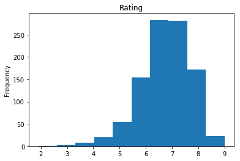

```python
movies_df['rating'].plot(kind='hist', title='Rating');
```

```python
movie_df.rating.value_count()
```

[output not shown]

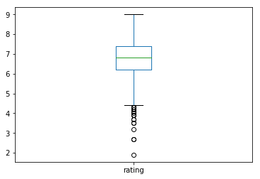

```python
movies_df['rating'].plot(kind="box");
```

```python
pd.DataFrame(movies_df['rating'].value_counts()).sort_values(by='rating')
```

|  | rating |
| --- | --- |
| 1.9 | 1 |
| 9.0 | 1 |
| 3.2 | 1 |
| 4.1 | 1 |
| 4.5 | 1 |
| 4.4 | 1 |
| 4.0 | 1 |
| 3.7 | 2 |
| 3.5 | 2 |
| 4.2 | 2 |
| 2.7 | 2 |
| 8.8 | 2 |
| 8.6 | 3 |
| 3.9 | 3 |
| 5.0 | 4 |
| 4.8 | 4 |
| 4.3 | 4 |
| 8.4 | 4 |
| 5.1 | 5 |
| 4.6 | 5 |
| 8.5 | 6 |
| 4.7 | 6 |
| 8.3 | 7 |
| 4.9 | 7 |
| 8.2 | 10 |
| 5.2 | 11 |
| 5.4 | 12 |
| 5.3 | 12 |
| 5.5 | 14 |
| 5.6 | 17 |
| 5.9 | 19 |
| 8.0 | 19 |
| 5.7 | 21 |
| 7.9 | 23 |
| 8.1 | 26 |
| 6.0 | 26 |
| 5.8 | 26 |
| 7.7 | 27 |
| 7.6 | 27 |
| 6.1 | 31 |
| 6.9 | 31 |
| 7.4 | 33 |
| 6.4 | 35 |
| 7.5 | 35 |
| 6.8 | 37 |
| 6.2 | 37 |
| 7.8 | 40 |
| 6.5 | 40 |
| 7.3 | 42 |
| 7.2 | 42 |
| 6.6 | 42 |
| 6.3 | 44 |
| 7.0 | 46 |
| 6.7 | 48 |
| 7.1 | 52 |

# Merging, joining, concatinating, appending

```python
#concat
import pandas as pd
df1 = pd.DataFrame(
    {
        "A": ["A0", "A1", "A2", "A3"],
        "B": ["B0", "B1", "B2", "B3"],
        "C": ["C0", "C1", "C2", "C3"],
        "D": ["D0", "D1", "D2", "D3"],
    },
    index=[0, 1, 2, 3],
)


df2 = pd.DataFrame(
    {
        "A": ["A4", "A5", "A6", "A7"],
        "B": ["B4", "B5", "B6", "B7"],
        "C": ["C4", "C5", "C6", "C7"],
        "D": ["D4", "D5", "D6", "D7"],
    },
    index=[4, 5, 6, 7],
)


df3 = pd.DataFrame(
    {
        "A": ["A8", "A9", "A10", "A11"],
        "B": ["B8", "B9", "B10", "B11"],
        "C": ["C8", "C9", "C10", "C11"],
        "D": ["D8", "D9", "D10", "D11"],
    },
    index=[8, 9, 10, 11],
)
```

```python
df1
```

|  | A | B | C | D |
| --- | --- | --- | --- | --- |
| 0 | A0 | B0 | C0 | D0 |
| 1 | A1 | B1 | C1 | D1 |
| 2 | A2 | B2 | C2 | D2 |
| 3 | A3 | B3 | C3 | D3 |

```python
df2
```

|  | A | B | C | D |
| --- | --- | --- | --- | --- |
| 4 | A4 | B4 | C4 | D4 |
| 5 | A5 | B5 | C5 | D5 |
| 6 | A6 | B6 | C6 | D6 |
| 7 | A7 | B7 | C7 | D7 |

```python
df3
```

|  | A | B | C | D |
| --- | --- | --- | --- | --- |
| 8 | A8 | B8 | C8 | D8 |
| 9 | A9 | B9 | C9 | D9 |
| 10 | A10 | B10 | C10 | D10 |
| 11 | A11 | B11 | C11 | D11 |

[figure not shown]

```python
frames = [df1, df2, df3]

result = pd.concat(frames,axis=0)
```

```python
result1 = pd.concat([df1,df2,df3],axis=0)
```

```python
result1
```

|  | A | B | C | D |
| --- | --- | --- | --- | --- |
| 0 | A0 | B0 | C0 | D0 |
| 1 | A1 | B1 | C1 | D1 |
| 2 | A2 | B2 | C2 | D2 |
| 3 | A3 | B3 | C3 | D3 |
| 4 | A4 | B4 | C4 | D4 |
| 5 | A5 | B5 | C5 | D5 |
| 6 | A6 | B6 | C6 | D6 |
| 7 | A7 | B7 | C7 | D7 |
| 8 | A8 | B8 | C8 | D8 |
| 9 | A9 | B9 | C9 | D9 |
| 10 | A10 | B10 | C10 | D10 |
| 11 | A11 | B11 | C11 | D11 |

```python
#Append
s2 = pd.Series(["X0", "X1", "X2", "X3"], index=["A", "B", "C", "D"])

result = pd.concat([df1, s2.to_frame().T], ignore_index=True)
```

```python
df1
```

|  | A | B | C | D |
| --- | --- | --- | --- | --- |
| 0 | A0 | B0 | C0 | D0 |
| 1 | A1 | B1 | C1 | D1 |
| 2 | A2 | B2 | C2 | D2 |
| 3 | A3 | B3 | C3 | D3 |

```python
s2
```

```
A    X0
B    X1
C    X2
D    X3
dtype: object
```

```python
s2.to_frame().T
```

|  | A | B | C | D |
| --- | --- | --- | --- | --- |
| 0 | X0 | X1 | X2 | X3 |

```python
result
```

|  | A | B | C | D |
| --- | --- | --- | --- | --- |
| 0 | A0 | B0 | C0 | D0 |
| 1 | A1 | B1 | C1 | D1 |
| 2 | A2 | B2 | C2 | D2 |
| 3 | A3 | B3 | C3 | D3 |
| 4 | X0 | X1 | X2 | X3 |

```python
#df['new_sal']= df['sal']*1.2
```

```python
#join
left = pd.DataFrame(
    {
        "key": ["K0", "K1", "K2", "K3"],
        "A": ["A0", "A1", "A2", "A3"],
        "B": ["B0", "B1", "B2", "B3"],
    }
)


right = pd.DataFrame(
    {
        "key": ["K0", "K1", "K2", "K2"],
        "C": ["C0", "C1", "C2", "C3"],
        "D": ["D0", "D1", "D2", "D3"],
    }
)


result = pd.merge(left, right, on="key")
```

```python
left
```

|  | key | A | B |
| --- | --- | --- | --- |
| 0 | K0 | A0 | B0 |
| 1 | K1 | A1 | B1 |
| 2 | K2 | A2 | B2 |
| 3 | K3 | A3 | B3 |

```python
right
```

|  | key | C | D |
| --- | --- | --- | --- |
| 0 | K0 | C0 | D0 |
| 1 | K1 | C1 | D1 |
| 2 | K2 | C2 | D2 |
| 3 | K2 | C3 | D3 |

```python
result
```

|  | key | A | B | C | D |
| --- | --- | --- | --- | --- | --- |
| 0 | K0 | A0 | B0 | C0 | D0 |
| 1 | K1 | A1 | B1 | C1 | D1 |
| 2 | K2 | A2 | B2 | C2 | D2 |
| 3 | K2 | A2 | B2 | C3 | D3 |

```python
result = pd.merge(left, right, how="left", on=["key"])
result
```

|  | key | A | B | C | D |
| --- | --- | --- | --- | --- | --- |
| 0 | K0 | A0 | B0 | C0 | D0 |
| 1 | K1 | A1 | B1 | C1 | D1 |
| 2 | K2 | A2 | B2 | C2 | D2 |
| 3 | K2 | A2 | B2 | C3 | D3 |
| 4 | K3 | A3 | B3 | NaN | NaN |

```python
left = pd.DataFrame(
    {
        "key1": ["K0", "K0", "K1", "K2"],
        "key2": ["K0", "K1", "K0", "K1"],
        "A": ["A0", "A1", "A2", "A3"],
        "B": ["B0", "B1", "B2", "B3"],
    }
)


right = pd.DataFrame(
    {
        "key1": ["K0", "K1", "K1", "K2"],
        "key2": ["K0", "K0", "K0", "K0"],
        "C": ["C0", "C1", "C2", "C3"],
        "D": ["D0", "D1", "D2", "D3"],
    }
)


result = pd.merge(left, right, on=["key1", "key2"])
```

```python
left
```

|  | key1 | key2 | A | B |
| --- | --- | --- | --- | --- |
| 0 | K0 | K0 | A0 | B0 |
| 1 | K0 | K1 | A1 | B1 |
| 2 | K1 | K0 | A2 | B2 |
| 3 | K2 | K1 | A3 | B3 |

```python
right
```

|  | key1 | key2 | C | D |
| --- | --- | --- | --- | --- |
| 0 | K0 | K0 | C0 | D0 |
| 1 | K1 | K0 | C1 | D1 |
| 2 | K1 | K0 | C2 | D2 |
| 3 | K2 | K0 | C3 | D3 |

```python
result
```

|  | key1 | key2 | A | B | C | D |
| --- | --- | --- | --- | --- | --- | --- |
| 0 | K0 | K0 | A0 | B0 | C0 | D0 |
| 1 | K1 | K0 | A2 | B2 | C1 | D1 |
| 2 | K1 | K0 | A2 | B2 | C2 | D2 |

```python
result = pd.merge(left, right, how="left", on=["key1", "key2"])
result
```

|  | key1 | key2 | A | B | C | D |
| --- | --- | --- | --- | --- | --- | --- |
| 0 | K0 | K0 | A0 | B0 | C0 | D0 |
| 1 | K0 | K1 | A1 | B1 | NaN | NaN |
| 2 | K1 | K0 | A2 | B2 | C1 | D1 |
| 3 | K1 | K0 | A2 | B2 | C2 | D2 |
| 4 | K2 | K1 | A3 | B3 | NaN | NaN |

```python
# Merging
df1 = pd.DataFrame({"col1": [0, 1], "col_left": ["a", "b"]})

df2 = pd.DataFrame({"col1": [1, 2, 2], "col_right": [2, 2, 2]})

pd.merge(df1, df2, on="col1", how="left", indicator=True)
```

|  | col1 | col_left | col_right | _merge |
| --- | --- | --- | --- | --- |
| 0 | 0 | a | NaN | left_only |
| 1 | 1 | b | 2.0 | both |

```python
df1
```

|  | col1 | col_left |
| --- | --- | --- |
| 0 | 0 | a |
| 1 | 1 | b |

```python
df2
```

|  | col1 | col_right |
| --- | --- | --- |
| 0 | 1 | 2 |
| 1 | 2 | 2 |
| 2 | 2 | 2 |

```python
movies_df.head()
```

|  | rank | title | genre | description | director | actors | year | runtime (minutes) | rating | votes | revenue (millions) | metascore |
| --- | --- | --- | --- | --- | --- | --- | --- | --- | --- | --- | --- | --- |
| 0 | 1 | Guardians of the Galaxy | Action,Adventure,Sci-Fi | A group of intergalactic criminals are forced ... | James Gunn | Chris Pratt, Vin Diesel, Bradley Cooper, Zoe S... | 2014 | 121 | 8.1 | 757074 | 333.13 | 76.0 |
| 1 | 2 | Prometheus | Adventure,Mystery,Sci-Fi | Following clues to the origin of mankind, a te... | Ridley Scott | Noomi Rapace, Logan Marshall-Green, Michael Fa... | 2012 | 124 | 7.0 | 485820 | 126.46 | 65.0 |
| 2 | 3 | Split | Horror,Thriller | Three girls are kidnapped by a man with a diag... | M. Night Shyamalan | James McAvoy, Anya Taylor-Joy, Haley Lu Richar... | 2016 | 117 | 7.3 | 157606 | 138.12 | 62.0 |
| 3 | 4 | Sing | Animation,Comedy,Family | In a city of humanoid animals, a hustling thea... | Christophe Lourdelet | Matthew McConaughey,Reese Witherspoon, Seth Ma... | 2016 | 108 | 7.2 | 60545 | 270.32 | 59.0 |
| 4 | 5 | Suicide Squad | Action,Adventure,Fantasy | A secret government agency recruits some of th... | David Ayer | Will Smith, Jared Leto, Margot Robbie, Viola D... | 2016 | 123 | 6.2 | 393727 | 325.02 | 40.0 |

```python
import numpy as np
pivot =pd.pivot_table(movies_df, values='revenue (millions)',
                                index=['year'],
                                #columns=['year'],
                                aggfunc=np.sum,
                                fill_value=0)
pivot
```

| year | revenue (millions) |
| --- | --- |
| 2006 | 3624.46 |
| 2007 | 4306.23 |
| 2008 | 5053.22 |
| 2009 | 5292.26 |
| 2010 | 5989.65 |
| 2011 | 5431.96 |
| 2012 | 6910.29 |
| 2013 | 7666.72 |
| 2014 | 7997.40 |
| 2015 | 8854.12 |
| 2016 | 11211.65 |